# Oragne Roughy Eastern Zone Survey Data

Bioloigical Data from 1987 to 2016

Caroline Sutton

CSIRO Oceans and Atmosphere

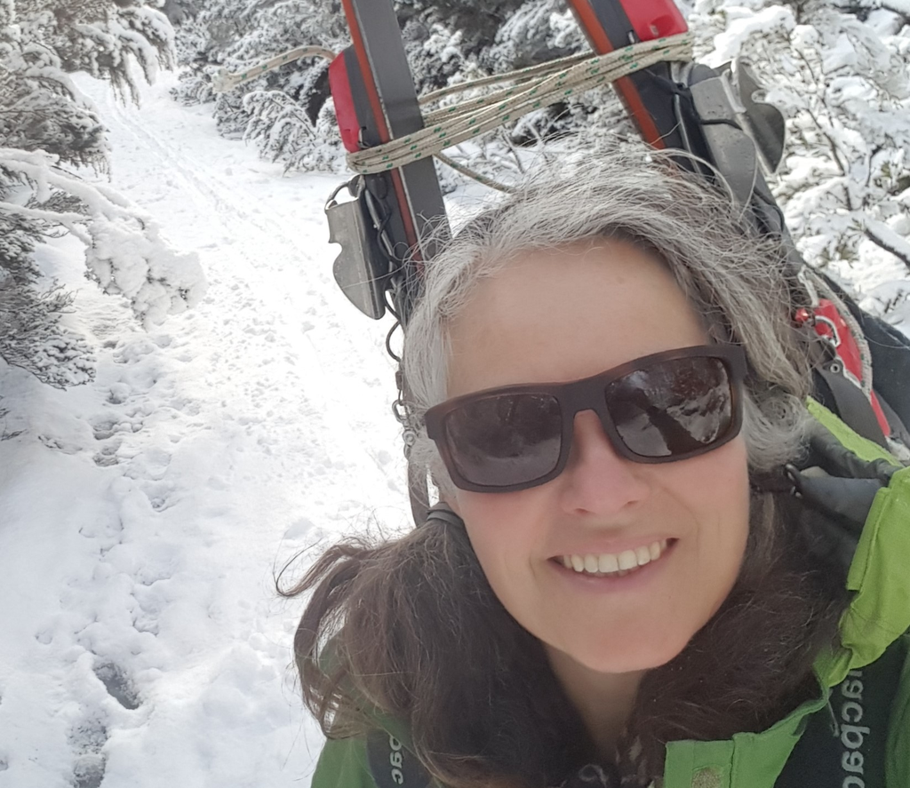

# Introduction

I’m a biologist with CSIRO’s Marine Resources and Industries working in the Acoustics & Pelagic Ecosystems Team. I manage the biological data and specimen collections within the group. This includes collecting, collating, standardising and analysing historical and new data. I learned to code at Data School. Prior to Data School I managed my data and conducted statistical analyses using Excel, Access and Systat.

# My Project: Orange Roughy Eastern Zone Spawning Population Biomass Survey Data from 1987 to 2016

CSIRO has conducted acoustic and biological surveys from 1987 to the present to estimate the spawning biomass of Orange Roughy for stock assessment. Data from 2019 have been excluded from this report because of commercial in confidence concerns. The data used for this project were collected aboard commercial trawlers from the spawning grounds located on seamounts off the east coast of Tasmania. The biological data include standard length (cm), sex, weight, gonad stage and a record of samples collected such as otoliths for aging and tissue samples for fecundity and toxicity analyses. Biological measurements such as standard length, which have been consistently measured and recorded since the fishery began can be used to assess if there have been changes in population size structure over time.

## **Tables**

```r
knitr::kable(tail(Roughy, n = 5), format = "html", caption = "My tidy data") %>%
  kableExtra::kable_styling("striped") %>%
  kableExtra::scroll_box(width = "100%")
```

Table 1: My tidy data

| X1 | zone.x | year | month | Area.x | Survey | Shot | FishNo | sex | stage | weight_kg | SL_cm | SLadj_cm | Otoliths | mark | ID | Survey2 | vessel | Voyage No | Year | zone.y | Area.y | Shot (Trawl no) | Operation | Trawl No (txt) | Date | Recorder | Shot type | lat1 | long1 | … |
| --- | --- | --- | --- | --- | --- | --- | --- | --- | --- | --- | --- | --- | --- | --- | --- | --- | --- | --- | --- | --- | --- | --- | --- | --- | --- | --- | --- | --- | --- | --- |
| 34165 | Eastern | 2016 | Jul | St Helens | EP2016 | 11 | 265 | F | 4 | 2.7 | 43 | 43 | TRUE | NA | 1144 | EP2016 | Empress Pearl | 1 | 2016 | Eastern | St Helens | NA | 11 | 11 | 2016-07-17 | NA | AOS biological | 41.24 | 148.77 | … |
| 34166 | Eastern | 2016 | Jul | St Helens | EP2016 | 15 | 739 | F | 6 | NA | 43 | 44 | NA | NA | 1132 | EP2016 | Empress Pearl | 1 | 2016 | Eastern | St Helens | NA | 15 | 15 | 2016-07-19 | NA | AOS biological | 41.24 | 148.76 | … |
| 34167 | Eastern | 2016 | Jul | St Helens | EP2016 | 18 | 824 | F | 5 | 2.8 | 44 | 44 | TRUE | NA | 1147 | EP2016 | Empress Pearl | 1 | 2016 | Eastern | St Helens | NA | 18 | 18 | 2016-07-19 | NA | Biological sample, no AOS | 41.25 | 148.76 | … |
| 34168 | Eastern | 2016 | Jul | St Helens | EP2016 | 18 | 901 | F | 4 | NA | 44 | 45 | NA | NA | 1147 | EP2016 | Empress Pearl | 1 | 2016 | Eastern | St Helens | NA | 18 | 18 | 2016-07-19 | NA | Biological sample, no AOS | 41.25 | 148.76 | … |
| 34169 | Eastern | 2016 | Jul | St Helens | EP2016 | 26 | 1530 | F | 4 | 2.5 | 45 | 45 | TRUE | NA | 1152 | EP2016 | Empress Pearl | 1 | 2016 | Eastern | St Helens | NA | 26 | 26 | 2016-07-20 | NA | Biological sample, no AOS | 41.25 | 148.74 | … |

## **How to measure the standard length of an orange roughy**

The Standard Length of an orange roughy is measured from the tip of the snout to the end of the hypural plate. The figures below show the location of the hypural plate.

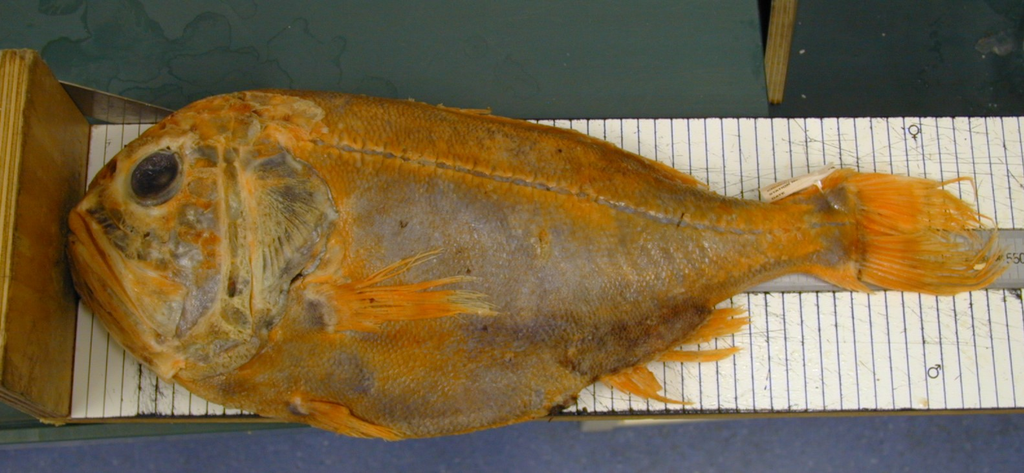

[output not shown]

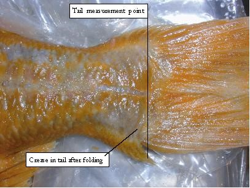